# ucscthemes

[figure not shown]

[figure not shown]

The goal of ucscthemes is to provide branded templates for the University of Cattolica for commonly used R markdown packages. Currently the package contains:

- Presentation template for the [xaringan](https://slides.yihui.org/xaringan/#1)-package
- Tutorial template for the [learnr](https://rstudio.github.io/learnr/)-package
- Website template for the [distill](https://rstudio.github.io/distill/website.html)-package
- Article template for the [distill](https://rstudio.github.io/distill/basics.html)-package
- Themes for the [ggplot2](https://ggplot2.tidyverse.org/)-package
- Colour and fill scales for the [ggplot2](https://ggplot2.tidyverse.org/)-package
- Course themed skeleton creation based on [bs4](https://pkgs.rstudio.com/bookdown/reference/bs4_book.html)

## Installation

You can install ucscthemes from github

```r
# install.packages("remotes")
remotes::install_github("NiccoloSalvini/ucscthemes")
```

## Basic usage

xaringan presentation, learnr tutorial and distill article templates with ucsc branding can be access easily using the RStudio IDE, by selecting `File` -> `R markdown ...` -> `From Template`.

Distill website template can be access most easily through the RStudio IDE to create a new project. `File` -> `New project...` -> `New Directory` -> `ucsc Distill Website`

**Previews**

### ggplot2 branding

The ggplot branding is applied through themes and scales.

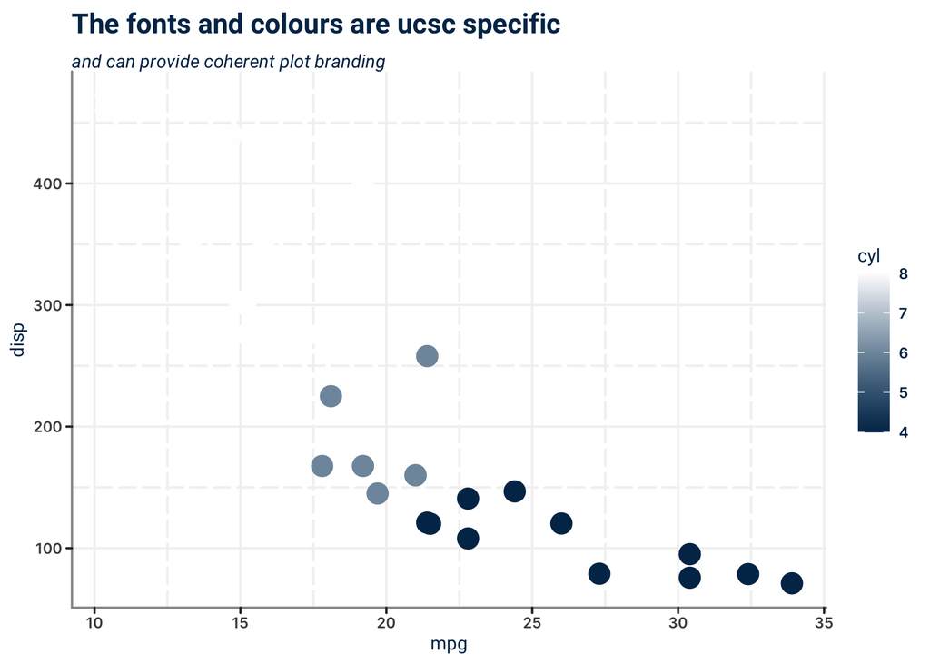

```r
library(ucscthemes)
library(ggplot2)

## issue with font theme

ggplot(mtcars, aes(mpg, disp, colour = cyl)) +
  geom_point(size = 5) +
  scale_colour_ucsc(discrete = FALSE) +
  labs(title = "The fonts and colours are ucsc specific",
       subtitle = "and can provide coherent plot branding")+
  theme_ucsc()
```

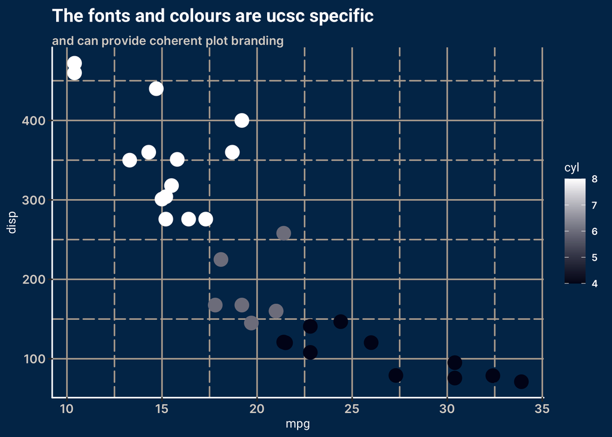

```r
ggplot(mtcars, aes(mpg, disp, colour = cyl)) +
  geom_point(size = 5) +
  scale_colour_ucsc(palette = "bw", discrete = FALSE) +
  theme_ucsc_dark() +
  labs(title = "The fonts and colours are ucsc specific",
       subtitle = "and can provide coherent plot branding")
```

## ucsc course skeleton

This package also offers a way to set up a minimal skeleton infrastructure to reproduce materials for a general course with [bs4](https://getbootstrap.com/docs/4.0/getting-started/introduction/) and [Bookdown](https://bookdown.org/) … [an example of a course built with this package](https://sbd-labs-22-23.netlify.app/).